# Data Science for Industry Short Course Assignment

Niel Kemp

21 August 2019

## Introduction

This report deals with the analysis of sentiments of complaints received by the US Consumer Financial Protection Bureau. The complaints are regarding financial products and services. The analysis in this report deals with a pre-prepared subset of 20,000 complaints. The full dataset can be downloaded at: https://catalog.data.gov/dataset/consumer-complaint-database

## Approach

### Libraries and data loading

The following R-packages were used, these can be obtained from CRAN:

- tidyverse
- stringr
- tidytext
- lubridate

The dataset contained in *complaints.RData* is loaded from the current working directly using the **load** function in R.

After the data is loaded we use **head** or **str** to investigate the top 5 rows of our dataset and some of the metadata

```
## # A tibble: 6 x 5
##   date_received product   consumer_complaint_narrat~ consumer_compen~    id
##   <chr>         <chr>     <chr>                      <lgl>            <int>
## 1 01/25/2016    Mortgage  "We bought a house in XXX~ FALSE                1
## 2 11/14/2015    Mortgage  "I got approved for a loa~ FALSE                2
## 3 10/13/2015    Credit r~ "As per the correspondenc~ FALSE                3
## 4 04/08/2016    Mortgage  "Regions Mortgage is not ~ TRUE                 4
## 5 06/11/2015    Debt col~ "Company calls continuall~ FALSE                5
## 6 04/12/2015    Credit r~ "I am writing to dispute ~ FALSE                6
```

```
## Classes 'tbl_df', 'tbl' and 'data.frame':    20000 obs. of  5 variables:
##  $ date_received               : chr  "01/25/2016" "11/14/2015" "10/13/2015" "04/08/2016" ...
##  $ product                     : chr  "Mortgage" "Mortgage" "Credit reporting" "Mortgage" ...
##  $ consumer_complaint_narrative: chr  "We bought a house in XXXX XXXX, CA -- XXXX/XXXX/XXXX. Our mortgage was handled by a company called XXXX. Soon a"| __truncated__ "I got approved for a loan to buy a house I have submitted everything I need to for them I paid for the inspecti"| __truncated__ "…
##  $ consumer_compensated        : logi  FALSE FALSE FALSE TRUE FALSE FALSE ...
##  $ id                          : int  1 2 3 4 5 6 7 8 9 10 ...
```

### Compensations by Product

Once the data is loaded and we have a feeling of the shape and formats of the relevant fields, we have a look at the prevalence of each type of complaint and how often they resulted in the consumer being compensated:

```
## # A tibble: 5 x 4
##   product                 complaints consumers_compensated  ratio
##   <chr>                        <int>                 <int>  <dbl>
## 1 Bank account or service       1935                   558 0.288
## 2 Credit card                   2740                   952 0.347
## 3 Credit reporting              4264                  1091 0.256
## 4 Debt collection               6027                  1027 0.170
## 5 Mortgage                      5034                   457 0.0908
```

From the above table it’s easy to see that the most often complained about product or area is Debt Collection, and then Mortgages. However, the areas where compensation is most often paid to consumers is the other 3 products, namely Bank Accounts or Services, Credit Card or Credit Reporting.

### Data Cleaning

Before we continue working with the data we need to do four things:

- Get the data into the tidy text format which is ‘one word per row’
- Remove stop words
- Add sentiments
- Calculate sentiment score of each complaint

#### Get data into tidy text format

The tidy text format is having only a single word per row in your dataset. In order to do this we use the *unnest_tokens* function with the token set to *words*. Using the token as *words* means that we’ll unnest the data into one word per row. This can also be set to *sentences* or to *regex* if you wish to use a more customized string/token.

Before and after version of the data is shown below:

##### Before

```
## # A tibble: 6 x 5
##   date_received product   consumer_complaint_narrat~ consumer_compen~    id
##   <chr>         <chr>     <chr>                      <lgl>            <int>
## 1 01/25/2016    Mortgage  "We bought a house in XXX~ FALSE                1
## 2 11/14/2015    Mortgage  "I got approved for a loa~ FALSE                2
## 3 10/13/2015    Credit r~ "As per the correspondenc~ FALSE                3
## 4 04/08/2016    Mortgage  "Regions Mortgage is not ~ TRUE                 4
## 5 06/11/2015    Debt col~ "Company calls continuall~ FALSE                5
## 6 04/12/2015    Credit r~ "I am writing to dispute ~ FALSE                6
```

##### After

```
## # A tibble: 6 x 5
##   date_received product  consumer_compensated    id word
##   <chr>         <chr>    <lgl>                <int> <chr>
## 1 01/25/2016    Mortgage FALSE                    1 we
## 2 01/25/2016    Mortgage FALSE                    1 bought
## 3 01/25/2016    Mortgage FALSE                    1 a
## 4 01/25/2016    Mortgage FALSE                    1 house
## 5 01/25/2016    Mortgage FALSE                    1 in
## 6 01/25/2016    Mortgage FALSE                    1 xxxx
```

#### Removing stop words

To remove stop words we use the lexicon of stop words that comes with **tidytext**. Below is a sample of 20 words from this lexicon of stop words.

```
##  [1] "it"          "tried"       "should"      "his"         "would"
##  [6] "that's"      "furthermore" "here's"      "two"         "seems"
## [11] "just"        "wonder"      "on"          "them"        "below"
## [16] "value"       "other"       "o"           "herself"     "rooms"
```

#### Adding Sentiments

After we’ve removed stop words and gotten our data into the tidy text format, we have one final step of data cleaning to do. We need to add sentiments to our dataset. To do this we’ll use the Bing sentiment dictionary that comes with the *tidytext* package.

Top 5 rows of the above mentioned dictionary can be seen below:

```
## # A tibble: 6 x 2
##   word       sentiment
##   <chr>      <chr>
## 1 2-faces    negative
## 2 abnormal   negative
## 3 abolish    negative
## 4 abominable negative
## 5 abominably negative
## 6 abominate  negative
```

We’ll use a left_join to add the sentiments to our dataset. We’ll also use an *ifelse* statement to change any sentiment that isn’t **positive** or **negative** to **neutral**

#### Calculate sentiment score of each complaint

The final step, is to calculate the **sentiment score** of each complaint. To do this, we simply subtract the number of words with a negative sentiment from the number of words with a positive sentiment for each complaint, ignoring words with a neutral sentiment. If the result is negative, then the complaint has a negative sentiment, if the result is positive, then the complaint has a positive sentiment.

Seeing as we’re working with a dataset full of *complaints*, the expectation is that we won’t see a lot of net-positive results. The result of the final cleaned up dataset is below:

```
## # A tibble: 6 x 5
## # Groups:   id, product [6]
##      id product          consumer_compensated netSentiment count
##   <int> <chr>            <lgl>                       <int> <int>
## 1     1 Mortgage         FALSE                          -4     1
## 2     2 Mortgage         FALSE                           1     1
## 3     3 Credit reporting FALSE                         -18     1
## 4     4 Mortgage         TRUE                           -4     1
## 5     5 Debt collection  FALSE                          -2     1
## 6     6 Credit reporting FALSE                           0     1
```

# Results

## Histogram of sentiment scores per product

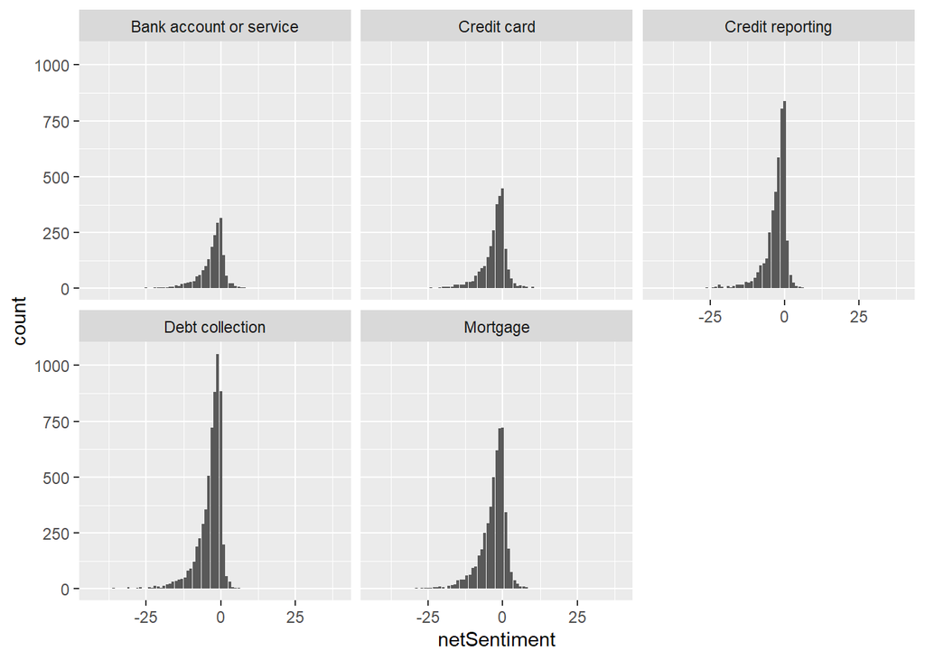

As expected, the vast majority of *complaints* are indeed negative. The amount by which they are negative vary greatly, but they are more often than not, negative.

Out of all the products, **Debt Collection** and **Mortgages** have the complaints that have the biggest negative sentiments, with some of them having a sentiment score as low as -25.